# Assignment 2 - Srujana Vanka, 2020102005

```r
library(readxl)
library(ggplot2)
library(corrplot)
library(MASS)
```

```r
library(ppcor)
library(carData)
```

```r
library(ltm)
```

```r
library(psych)
```

## 1 Advert Rating: Outlier Detection

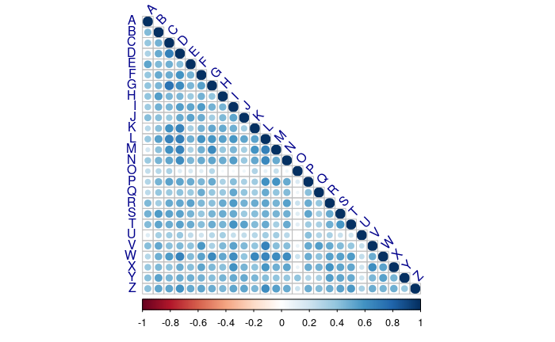

```r
data <- read_excel("BRSM_Assignment_2_datasets.xlsx", sheet = "Advert Rating")

cor_matrix <- cor(data)
corrplot(cor_matrix, type = "lower", tl.col = "darkblue", tl.srt = 45)
```

#### **Observations and Inferences:**

Upon examining the correlation heatmap, it becomes evident that participants ‘O’ and ‘U’ stand out as potential outliers. These individuals exhibit a striking characteristic - their correlation with almost every other participant is consistently zero.

This lack of correlation suggests a lack of linear relationship between the ratings provided by ‘O’ and ‘U’ and those of the other participants.

## 2 Reliable Job: Internal Consistency

```r
data <- read_excel("BRSM_Assignment_2_datasets.xlsx", sheet = "Reliable Job")
```

### 1. Calculate Cronbach’s Alpha for Job Satisfaction (JS):

```r
# Extract JS items
JS_items <- data[, c("JS1", "JS2", "JS3", "JS4")]

# Calculate Spearman correlations between JS items
cor_JS <- cor(JS_items, method = "spearman")

# Calculate mean correlation (lower triangle, excluding diagonal)
mean_cor_JS <- mean(cor_JS[lower.tri(cor_JS, diag = FALSE)])

# Calculate Cronbach's Alpha for JS
num_JS_items <- ncol(JS_items)
alpha_JS <- (num_JS_items / (num_JS_items - 1)) * (1 - (mean_cor_JS / (1 + mean_cor_JS)))

cat("Cronbach's Alpha for Job Satisfaction (JS):", alpha_JS, "\n")
```

```
Cronbach's Alpha for Job Satisfaction (JS): 0.8319978
```

### 2. Calculate Cronbach’s Alpha for Job Performance (JP):

```r
# Extract JP items
JP_items <- data[, c("JP1", "JP2", "JP3", "JP4")]

# Calculate Spearman correlations between JP items
cor_matrix_JP <- cor(JP_items, method = "spearman")

# Calculate mean correlation (lower triangle, excluding diagonal)
lower_tri_JP <- cor_matrix_JP[lower.tri(cor_matrix_JP)]

mean_corr_JP <- mean(lower_tri_JP)

n_JP <- ncol(JP_items)
alpha_JP <- n_JP * mean_corr_JP/(1 + (n_JP - 1)*mean_corr_JP)

cat("Cronbach's Alpha for Job Performance (JP):", alpha_JP, "\n")
```

```
Cronbach's Alpha for Job Performance (JP): 0.5242351
```

### Internal Consistency Analysis

1. **Job Satisfaction (JS):**
   - **Cronbach’s Alpha:** 0.8319978
   - **Commentary:** The Cronbach’s alpha for Job Satisfaction is 0.832, indicating a high level of internal consistency. This suggests that the questions related to job satisfaction are closely related and measure a common underlying construct reliably.
2. **Job Performance (JP):**
   - **Cronbach’s Alpha:** 0.5242351
   - **Commentary:** The Cronbach’s alpha for Job Performance is 0.525, which is below the commonly accepted threshold of 0.7. This suggests potential issues with internal consistency in the Job Performance questionnaire. It is advisable to review and possibly revise the items for improved reliability.

**Summary:** - Typically, Cronbach’s Alpha values range from 0 to 1, where higher values indicate better internal consistency. - An Alpha value above 0.7 is often considered acceptable for reliability. - The Job Satisfaction questionnaire demonstrates good internal consistency. - The Job Performance questionnaire may benefit from further examination and refinement of its items to enhance internal consistency.

## 3 Yulu: Normality Testing

### 1. Conduct exploratory analysis

```r
yulu_data <- read_excel("BRSM_Assignment_2_datasets.xlsx", sheet = "Yulu")
df <- yulu_data
```

Sampling is employed in statistical analyses, such as the Shapiro-Wilk test for normality, to manage issues related to sample size constraints.

The Shapiro-Wilk test assumes that the sample size falls within a specific range, typically between 3 and 5000 observations. When dealing with larger datasets that surpass this threshold, sampling becomes a crucial step to comply with the test requirements.

The purpose of sampling is to create a representative subset of the original data, allowing statistical analyses to be performed on a manageable and statistically valid scale. By randomly selecting a subset of the data, we ensure that the assumptions and properties of the statistical tests hold, preventing biases or inaccuracies that might arise due to excessively large sample sizes.

```
Shapiro-Wilk test for season (sampled data): Statistic = 0.856705 , p-value = 3.434503e-29
```

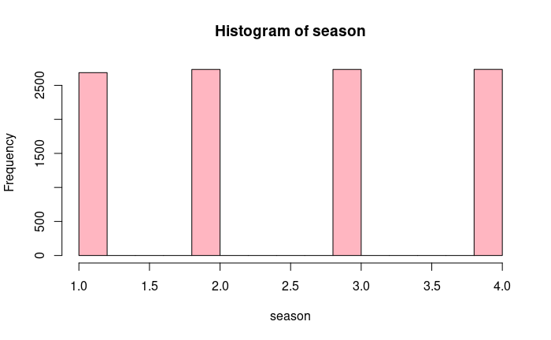

```
Shapiro-Wilk test for holiday (sampled data): Statistic = 0.1732696 , p-value = 1.91005e-54
```

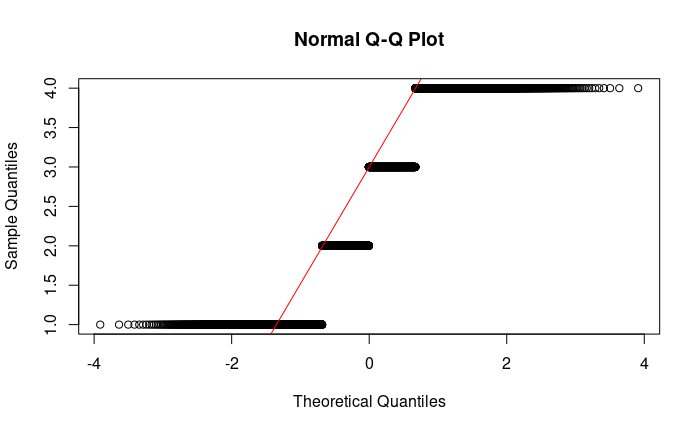

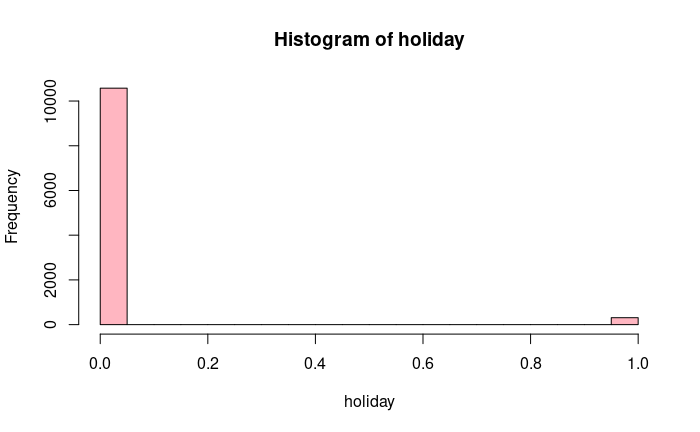

```
Shapiro-Wilk test for workingday (sampled data): Statistic = 0.573018 , p-value = 5.726442e-44
```

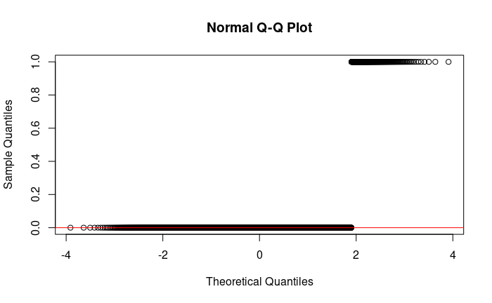

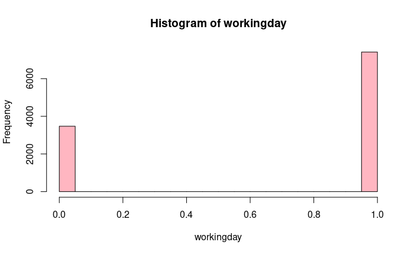

```
Shapiro-Wilk test for weather (sampled data): Statistic = 0.6414152 , p-value = 2.151611e-41
```

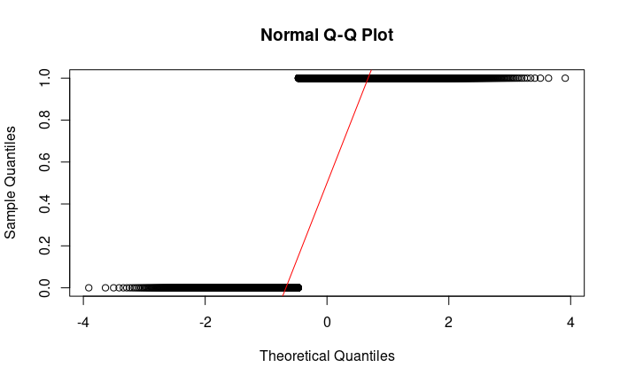

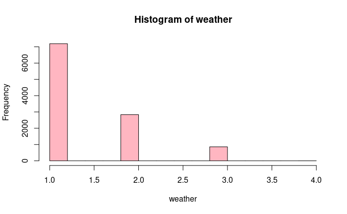

```
Shapiro-Wilk test for temp (sampled data): Statistic = 0.9810993 , p-value = 4.19952e-10
```

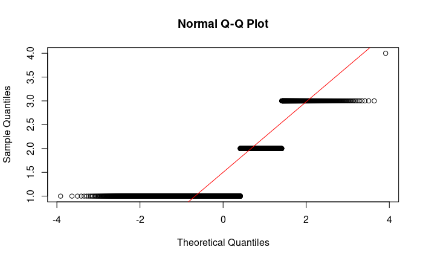

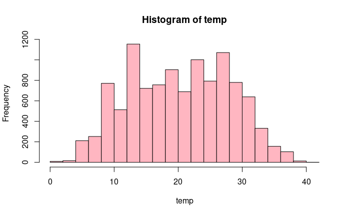

```
Shapiro-Wilk test for atemp (sampled data): Statistic = 0.9830694 , p-value = 2.250991e-09
```

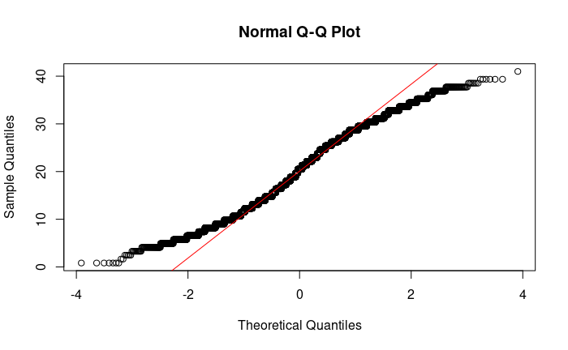

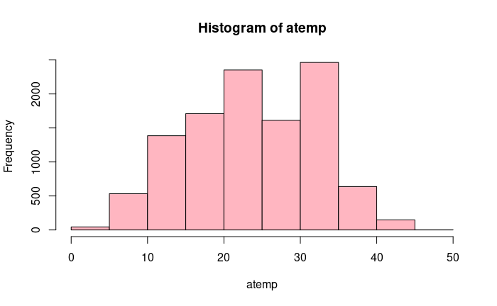

```
Shapiro-Wilk test for humidity (sampled data): Statistic = 0.9785663 , p-value = 5.642666e-11
```

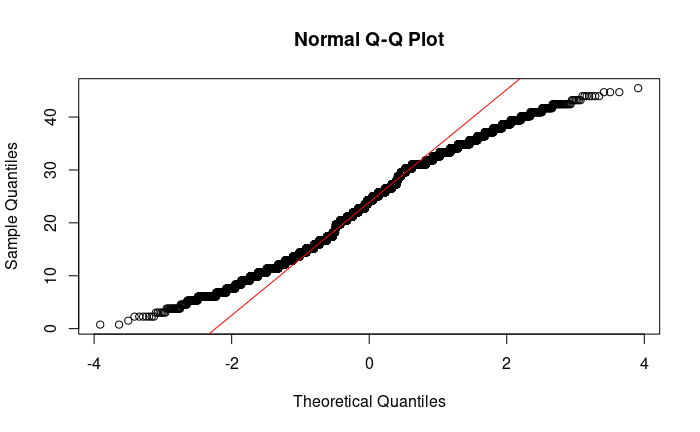

[10 more figures not shown]

```r
numeric_columns <- c('season', 'holiday', 'workingday', 'weather', 'temp', 'atemp', 'humidity', 'windspeed', 'casual', 'registered', 'count')

# Function for exploratory analysis and normality checks
explore_and_test_normality <- function(col) {
  # Check if the sample size is within the limit for Shapiro-Wilk test
  if (length(df[[col]]) > 5000) {
    # Set the desired sample size (e.g., 1000)
    desired_sample_size <- 1000

    # Take a random sample of size 'desired_sample_size'
    sampled_data <- sample(df[[col]], size = desired_sample_size)

    # Shapiro-Wilk test on the sampled data
    shapiro_test <- shapiro.test(sampled_data)
    cat("Shapiro-Wilk test for", col, "(sampled data): Statistic =", shapiro_test$statistic, ", p-value =", shapiro_test$p.value, "\n")
  } else {
    # Shapiro-Wilk test directly
    shapiro_test <- shapiro.test(df[[col]])
    cat("Shapiro-Wilk test for", col, ": Statistic =", shapiro_test$statistic, ", p-value =", shapiro_test$p.value, "\n")
  }

  # Histogram
  hist(df[[col]], main = paste("Histogram of", col), xlab = col, col = "lightpink", border = "black")

  # Q-Q plot
  qqnorm(df[[col]])
  qqline(df[[col]], col = 2)
}

# Apply the function for each numeric column
for (col in numeric_columns) {
  explore_and_test_normality(col)
}
```

### 2. Apply Box-Cox transformation if not normally distributed

```
Shapiro-Wilk test for season (sampled data): Statistic = 0.8633926 , p-value = 1.290382e-28
Box-Cox transformation applied for season
```

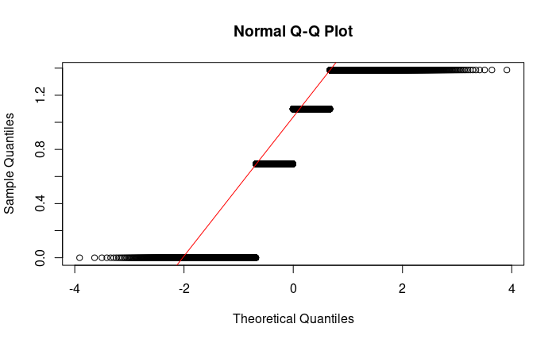

```
Shapiro-Wilk test for holiday (sampled data): Statistic = 0.1478553 , p-value = 5.932161e-55
Box-Cox transformation applied for holiday
```

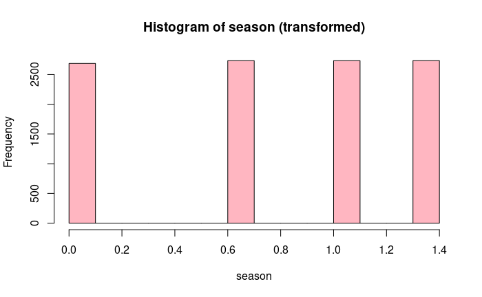

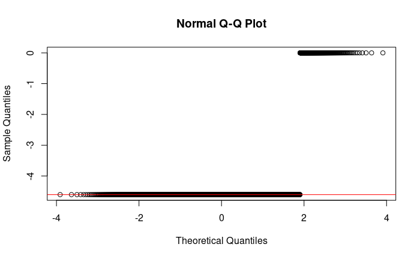

```
Shapiro-Wilk test for workingday (sampled data): Statistic = 0.5842002 , p-value = 1.427267e-43
Box-Cox transformation applied for workingday
```

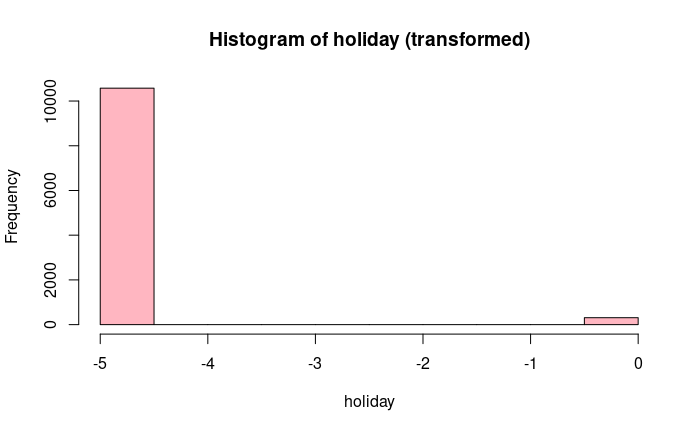

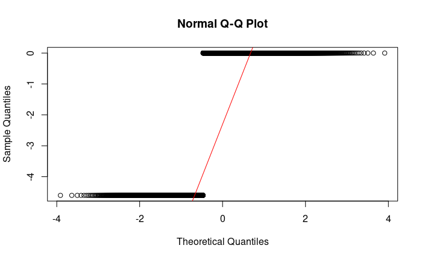

```
Shapiro-Wilk test for weather (sampled data): Statistic = 0.6546061 , p-value = 7.499497e-41
Box-Cox transformation applied for weather
```

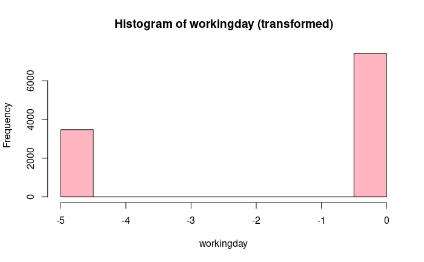

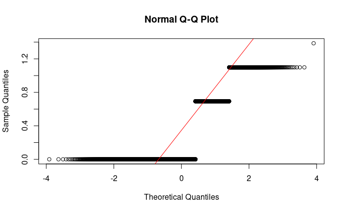

```
Shapiro-Wilk test for temp (sampled data): Statistic = 0.9782404 , p-value = 4.406632e-11
Box-Cox transformation applied for temp
```

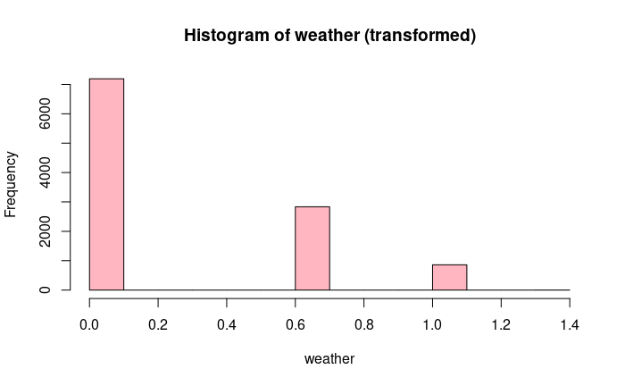

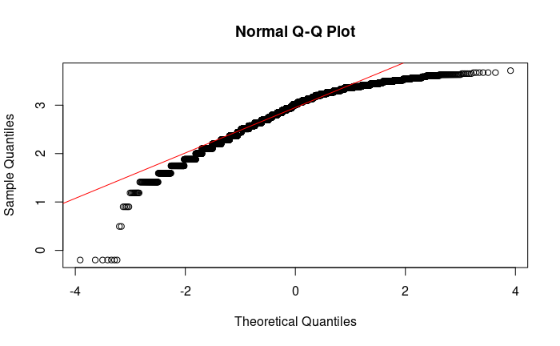

```
Shapiro-Wilk test for atemp (sampled data): Statistic = 0.9807313 , p-value = 3.106102e-10
Box-Cox transformation applied for atemp
```

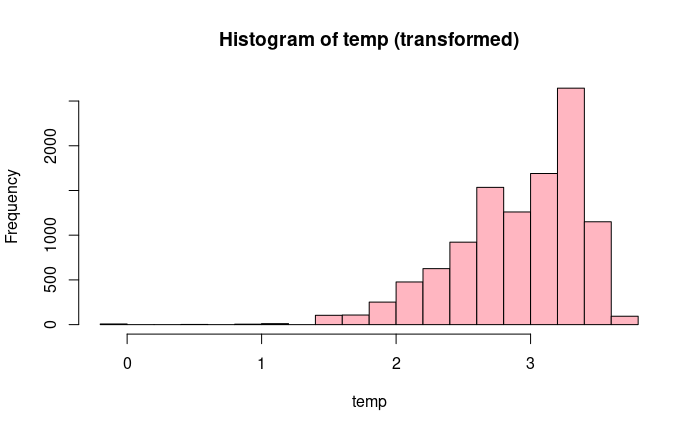

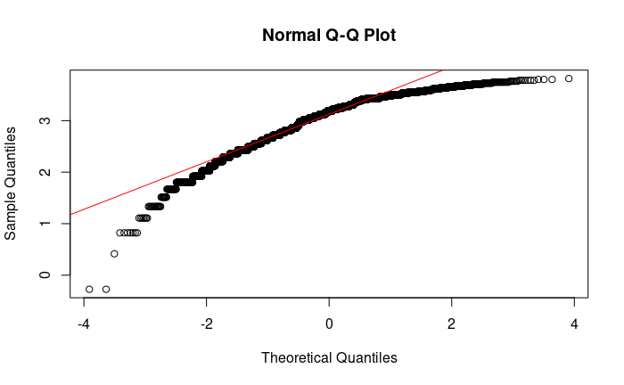

```
Shapiro-Wilk test for humidity (sampled data): Statistic = 0.9792964 , p-value = 9.904162e-11
Box-Cox transformation applied for humidity
```

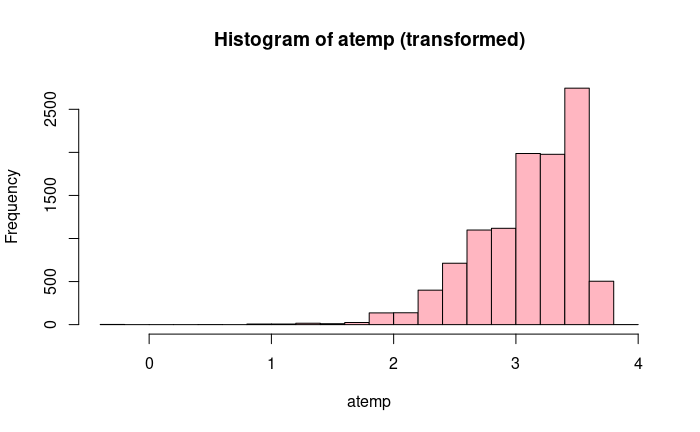

[10 more figures not shown]

```r
# Function to check normality and apply Box-Cox transformation
explore_and_transform <- function(col) {
  # Check if the sample size is within the limit for Shapiro-Wilk test
  if (length(df[[col]]) > 5000) {
    # Set the desired sample size (e.g., 1000)
    desired_sample_size <- 1000

    # Take a random sample of size 'desired_sample_size'
    sampled_data <- sample(df[[col]], size = desired_sample_size)

    # Shapiro-Wilk test on the sampled data
    shapiro_test <- shapiro.test(sampled_data)
    cat("Shapiro-Wilk test for", col, "(sampled data): Statistic =", shapiro_test$statistic, ", p-value =", shapiro_test$p.value, "\n")

    # Apply Box-Cox transformation for non-normally distributed variables
    if (shapiro_test$p.value < 0.05) {
      # Handling zero values by adding a small constant
      df[[col]] <- ifelse(df[[col]] == 0, 0.01, df[[col]])
      transformed_col <- log(df[[col]])
      cat("Box-Cox transformation applied for", col, "\n")

      # Plot QQ plot
      qqnorm(transformed_col)
      qqline(transformed_col, col = 2)

      # Plot histogram
      hist(transformed_col, main = paste("Histogram of", col, "(transformed)"), xlab = col, col = "lightpink", border = "black")
    }
  } else {
    # Shapiro-Wilk test directly
    shapiro_test <- shapiro.test(df[[col]])
    cat("Shapiro-Wilk test for", col, ": Statistic =", shapiro_test$statistic, ", p-value =", shapiro_test$p.value, "\n")

    # Apply Box-Cox transformation for non-normally distributed variables
    if (shapiro_test$p.value < 0.05) {
      # Handling zero values by adding a small constant
      df[[col]] <- ifelse(df[[col]] == 0, 0.01, df[[col]])
      transformed_col <- log(df[[col]])
      cat("Box-Cox transformation applied for", col, "\n")

      # Plot QQ plot
      qqnorm(transformed_col)
      qqline(transformed_col, col = 2)

      # Plot histogram
      hist(transformed_col, main = paste("Histogram of", col, "(transformed)"), xlab = col, col = "lightblue", border = "black")
    }
  }
}

# Apply the function for each numeric column
for (col in numeric_columns) {
  explore_and_transform(col)
}
```